# Eelgrass_community_structure_analyses

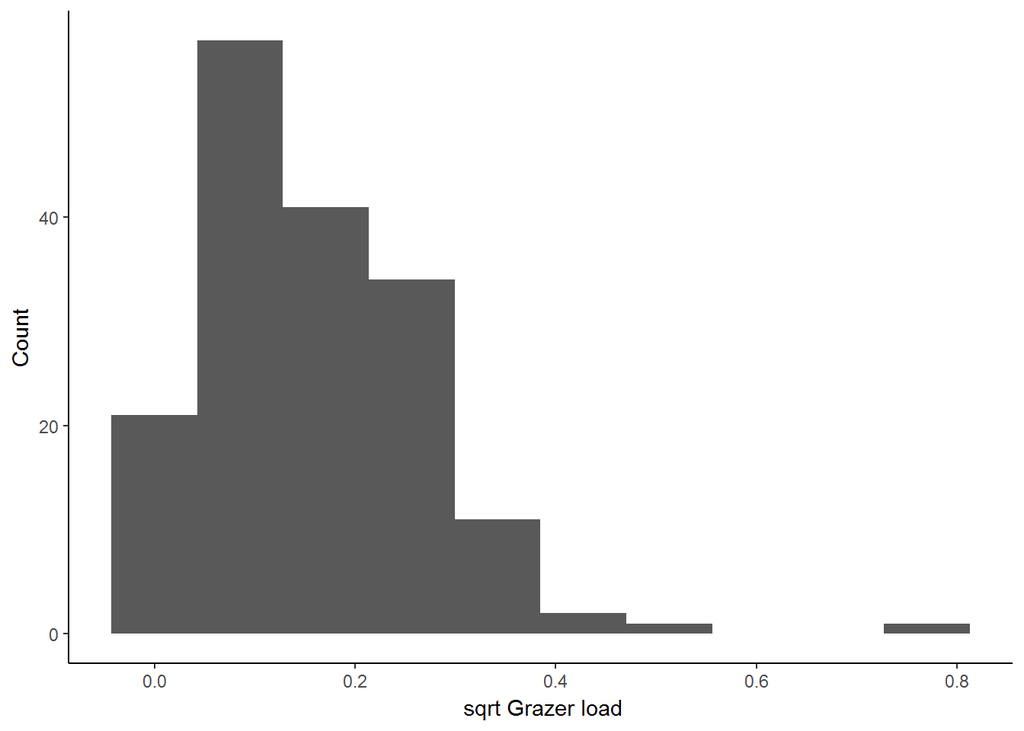

```
##
##  Shapiro-Wilk normality test
##
## data:  sqrt(tran.dat$grazmass_shootmass)
## W = 0.91578, p-value = 2.868e-08
```

Gastropod load also does not respond super well to transformations.

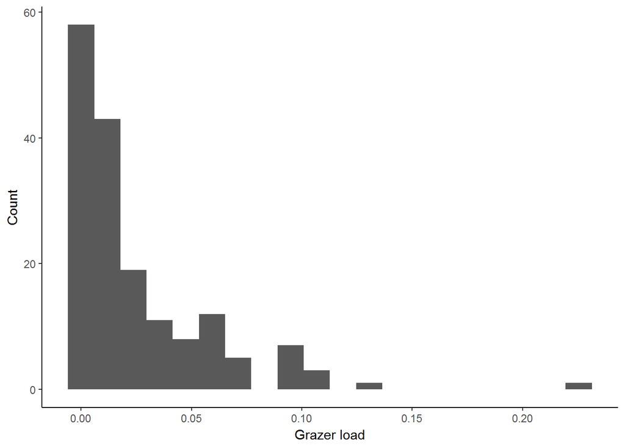

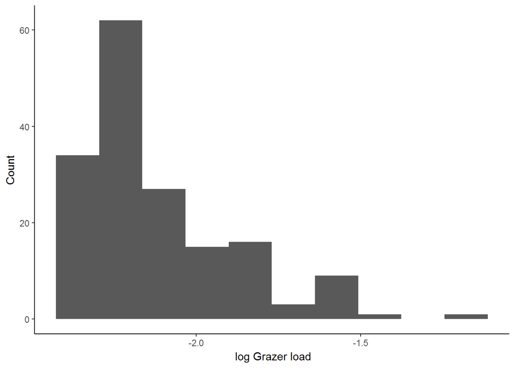

```
##
##  Shapiro-Wilk normality test
##
## data:  log(tran.dat$gastromass_shootmass + 0.1)
## W = 0.81818, p-value = 3.438e-13
```

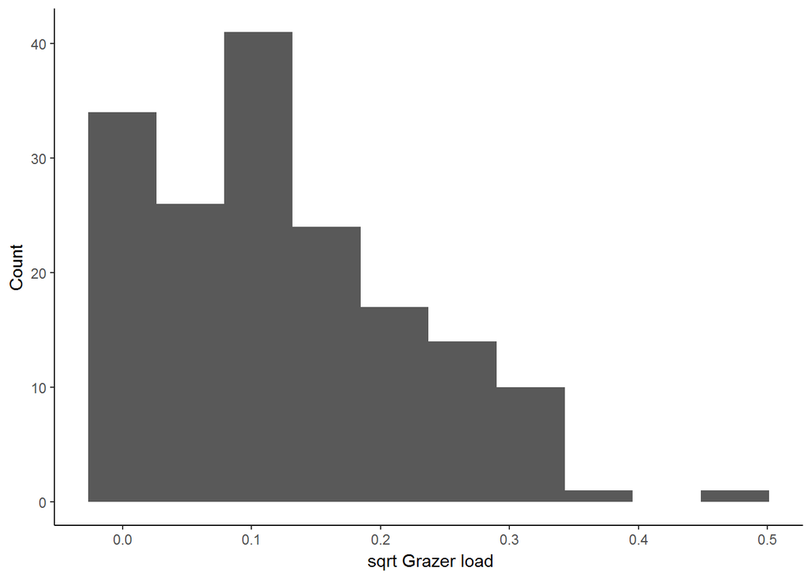

```
##
##  Shapiro-Wilk normality test
##
## data:  sqrt(tran.dat$gastromass_shootmass)
## W = 0.93516, p-value = 6.812e-07
```

Crab biomass does not respoond super well to any transformations. There are a fair amount of zeros which is messing with normality. This data may need to be modeled with a zero infalted model, or something like that. But the zeros are also really important to be zeros.

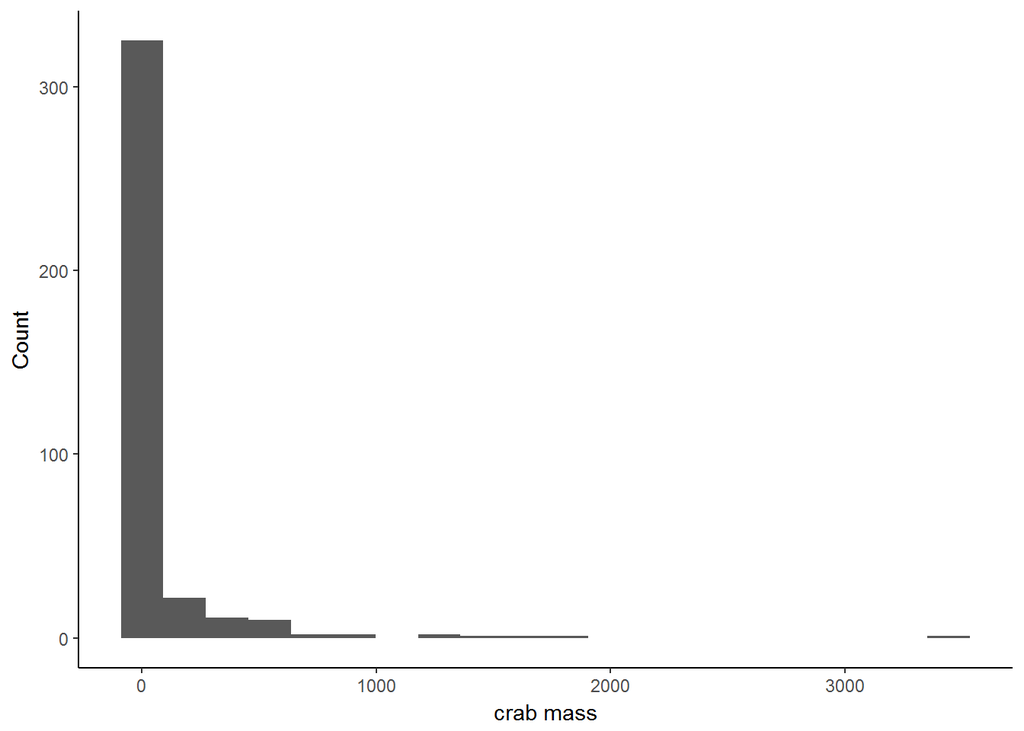

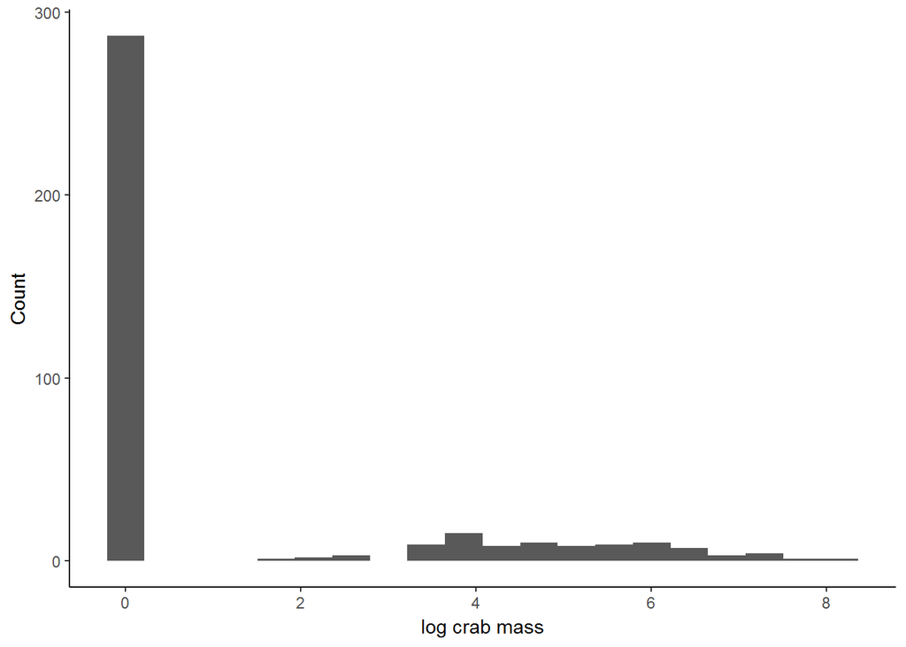

```
##
##  Shapiro-Wilk normality test
##
## data:  log(crab.dat$mass_g + 1)
## W = 0.58183, p-value < 2.2e-16
```

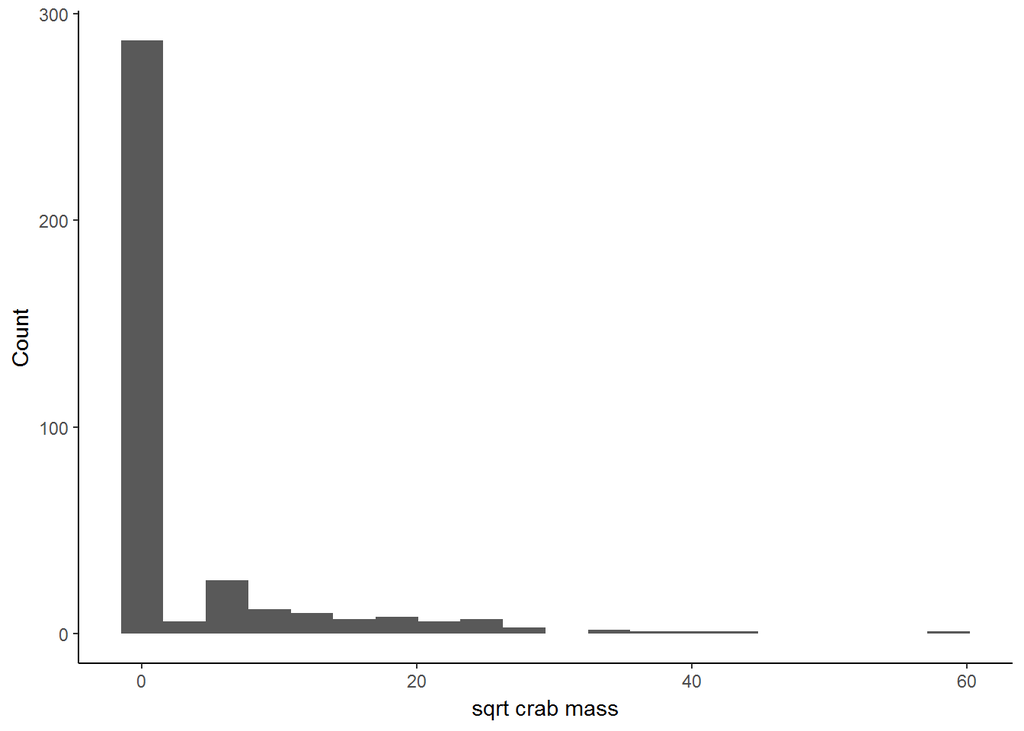

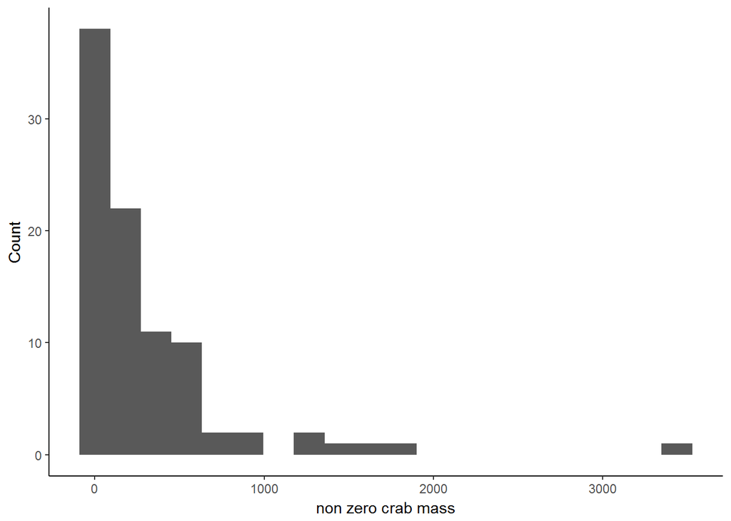

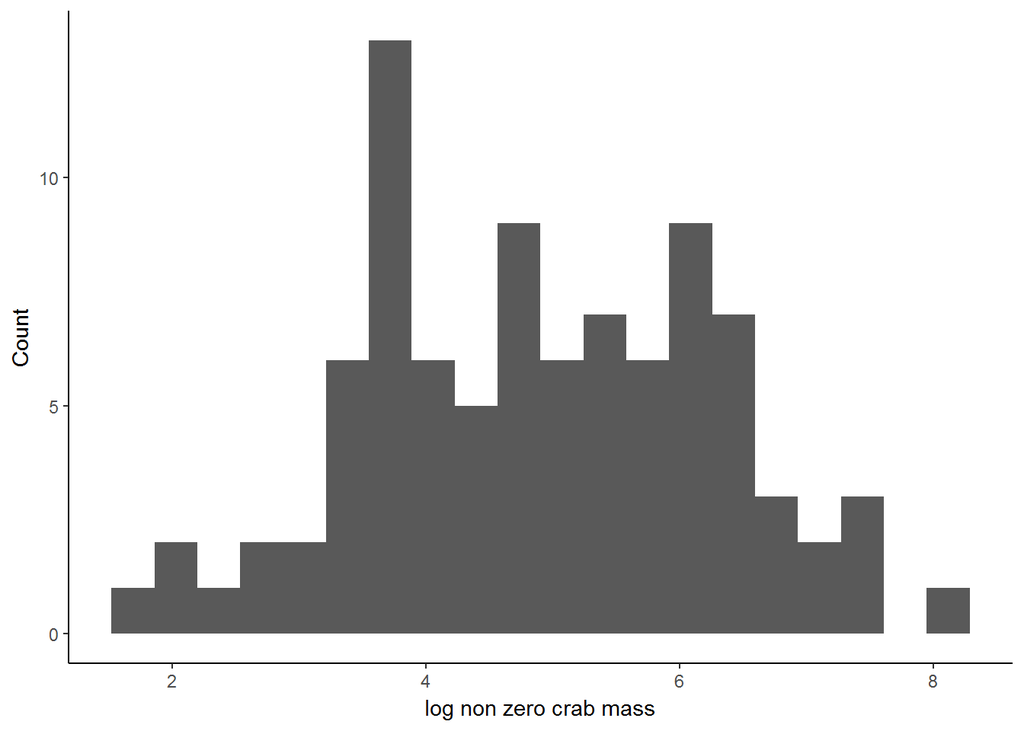

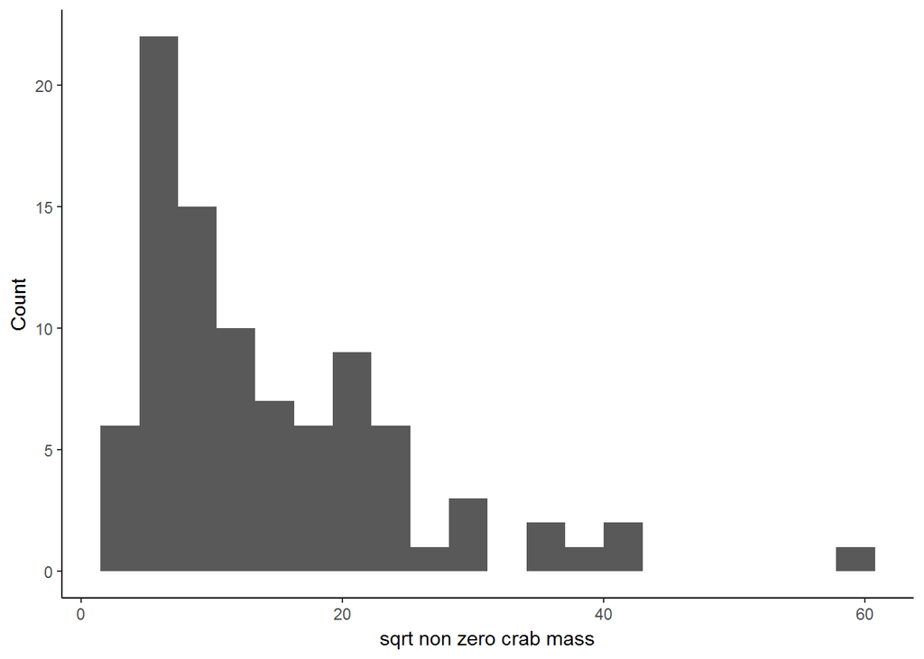

## 3. Models

Each model will get its own individual hypothesis and set up but will follow the same general framework. Initially I will be copying and learning from example code from Tim Tinker. Models will use a mixed effects Bayesian modeling stucture. Fixed effects and the random effect of site will be modeled with normally distribution density funtions. Response variables will be paramterized in a way that best fits their distribution (see above). Count data (shoot density) will be modeled with a negative binomial distrbution.

Models will exclude the two sites sampled in April. If the data have not already been excluded do that here.

### Model 1 - Aboveground biomass

Response - log normally distributed. We hypothesise that time (as julian day), sea otter index, sediment type, and light attenuation may effect aboveground biomass of eelgrass. Note that the number of samples (nsamples) will need to adjusted to suit the number of cores running on your machine so that the resulting analysis results in >= 20,000 samples. For example if you have 8 cores you can run analysis on 7 cores so nsamples should = 2900.

**Model 1a** Aboveground biomass ~ time

```
## module lecuyer loaded
```

```
## Compiling rjags model...
## Starting 7 rjags simulations using a PSOCK cluster with 7 nodes on
## host 'localhost'
## Simulation complete
## Note: Summary statistics were not produced as there are >50
## monitored variables
## [To override this behaviour see ?add.summary and ?runjags.options]
## FALSEFinished running the simulation
```

**Model 1b** Aboveground biomass ~ time + SOI

```
## Compiling rjags model...
## Starting 7 rjags simulations using a PSOCK cluster with 7 nodes on
## host 'localhost'
## Simulation complete
## Note: Summary statistics were not produced as there are >50
## monitored variables
## [To override this behaviour see ?add.summary and ?runjags.options]
## FALSEFinished running the simulation
```

**Model 1c** Aboveground biomass ~ time + SOI + sediment

```
## Compiling rjags model...
## Starting 7 rjags simulations using a PSOCK cluster with 7 nodes on
## host 'localhost'
## Simulation complete
## Note: Summary statistics were not produced as there are >50
## monitored variables
## [To override this behaviour see ?add.summary and ?runjags.options]
## FALSEFinished running the simulation
```

**Model 1d** Aboveground biomass ~ time + SOI + sediment + light

```
## Compiling rjags model...
## Starting 7 rjags simulations using a PSOCK cluster with 7 nodes on
## host 'localhost'
## Simulation complete
## Note: Summary statistics were not produced as there are >50
## monitored variables
## [To override this behaviour see ?add.summary and ?runjags.options]
## FALSEFinished running the simulation
```

**Model 1e** Aboveground biomass ~ time + quad(SOI)

```
## Compiling rjags model...
## Starting 7 rjags simulations using a PSOCK cluster with 7 nodes on
## host 'localhost'
## Simulation complete
## Note: Summary statistics were not produced as there are >50
## monitored variables
## [To override this behaviour see ?add.summary and ?runjags.options]
## FALSEFinished running the simulation
```

**Model 1f** Aboveground biomass ~ time + quad(SOI) + sediment

```
## Compiling rjags model...
## Starting 7 rjags simulations using a PSOCK cluster with 7 nodes on
## host 'localhost'
## Simulation complete
## Note: Summary statistics were not produced as there are >50
## monitored variables
## [To override this behaviour see ?add.summary and ?runjags.options]
## FALSEFinished running the simulation
```

**Model 1g** Aboveground biomass ~ quad(time) + SOI

```
## Compiling rjags model...
## Starting 7 rjags simulations using a PSOCK cluster with 7 nodes on
## host 'localhost'
## Simulation complete
## Note: Summary statistics were not produced as there are >50
## monitored variables
## [To override this behaviour see ?add.summary and ?runjags.options]
## FALSEFinished running the simulation
```

**Model 1h** Aboveground biomass ~ quad(time) + qaud(SOI)

```
## Compiling rjags model...
## Starting 7 rjags simulations using a PSOCK cluster with 7 nodes on
## host 'localhost'
## Simulation complete
## Note: Summary statistics were not produced as there are >50
## monitored variables
## [To override this behaviour see ?add.summary and ?runjags.options]
## FALSEFinished running the simulation
```

### Model 1 Comparison

### Model 1 Comparison tables

WAIC Comparison

|  | modID | model | WAIC | WAIC_se | deltaWAIC | deltaWAIC_se | P_comp | Likelihood | WAICwt |
| --- | --- | --- | --- | --- | --- | --- | --- | --- | --- |
| 7 | WAIC1g | 1g | 1516.272 | 29.944 | 0 | 0 | 1 | 1 | 0.216 |
| 8 | WAIC1h | 1h | 1516.353 | 30.137 | 0.04 | 0.727 | 0.478 | 0.98 | 0.211 |
| 5 | WAIC1e | 1e | 1516.651 | 29.97 | 0.189 | 1.061 | 0.429 | 0.91 | 0.196 |
| 2 | WAIC1b | 1b | 1516.715 | 29.808 | 0.221 | 0.698 | 0.376 | 0.895 | 0.193 |
| 1 | WAIC1a | 1a | 1516.905 | 29.743 | 0.316 | 1.016 | 0.378 | 0.854 | 0.184 |
| 4 | WAIC1d | 1d | 1519.199 | 29.72 | 1.463 | 0.924 | 0.057 | 0 | 0 |
| 6 | WAICf | 1f | 1519.215 | 29.935 | 0 | 0 | 0 | 0 | 0 |
| 3 | WAIC1c | 1c | 1519.276 | 29.709 | 1.502 | 0.785 | 0.028 | 0 | 0 |

LOICC comparison

|  | modID | model | LOOIC.looic | LOOIC_se | deltaLOOIC | deltaLOOIC_se | Likelihood | LOOICwt |
| --- | --- | --- | --- | --- | --- | --- | --- | --- |
| 7 | LOOIC1g | 1g | 1516.852 | 29.999 | 0 | 0 | 1 | 0.168 |
| 8 | LOOIC1h | 1h | 1516.92 | 30.194 | 0.034 | 0.733 | 0.983 | 0.165 |
| 5 | LOOIC1e | 1e | 1517.252 | 30.028 | 0.2 | 1.063 | 0.905 | 0.152 |
| 2 | LOOIC1b | 1b | 1517.33 | 29.87 | 0.239 | 0.691 | 0.887 | 0.149 |
| 1 | LOOIC1a | 1a | 1517.529 | 29.802 | 0.339 | 1.02 | 0.844 | 0.141 |
| 4 | LOOIC1d | 1d | 1519.995 | 29.801 | 1.571 | 0.94 | 0.456 | 0.076 |
| 6 | LOOIC1f | 1f | 1520.01 | 30.018 | 1.579 | 1.095 | 0.454 | 0.076 |
| 3 | LOOIC1c | 1c | 1520.156 | 29.803 | 1.652 | 0.8 | 0.438 | 0.073 |

```
## Calculating summary statistics...
## Calculating the Gelman-Rubin statistic for 7 variables....
```

```
## Generating summary statistics and plots (these will NOT be saved
## for reuse)...
## Calculating summary statistics...
## Calculating the Gelman-Rubin statistic for 7 variables....
```

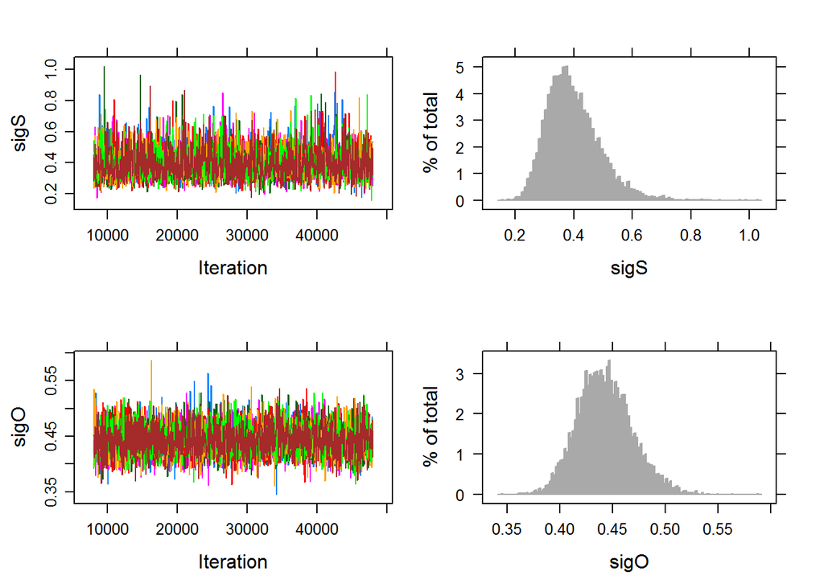

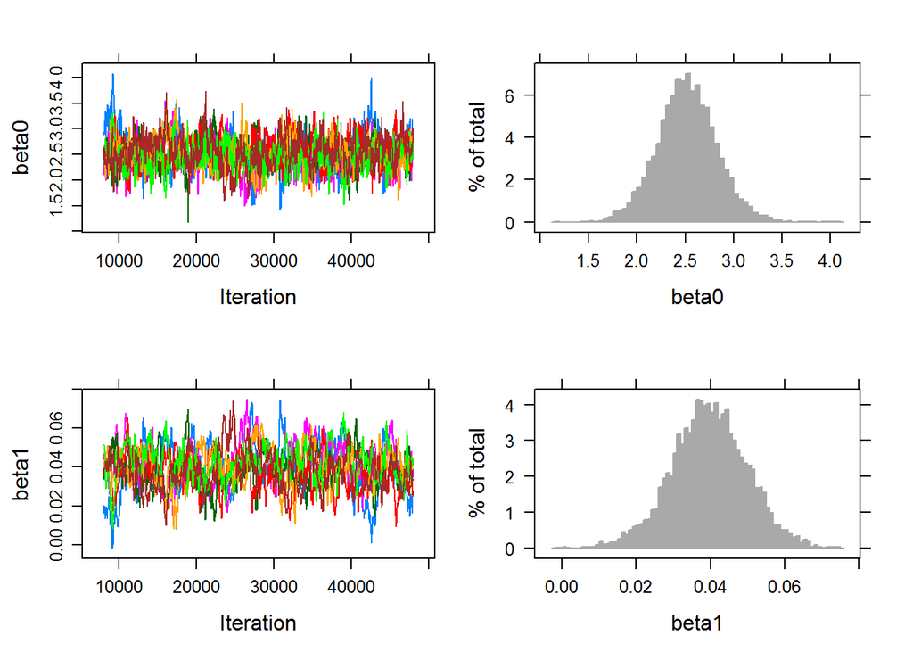

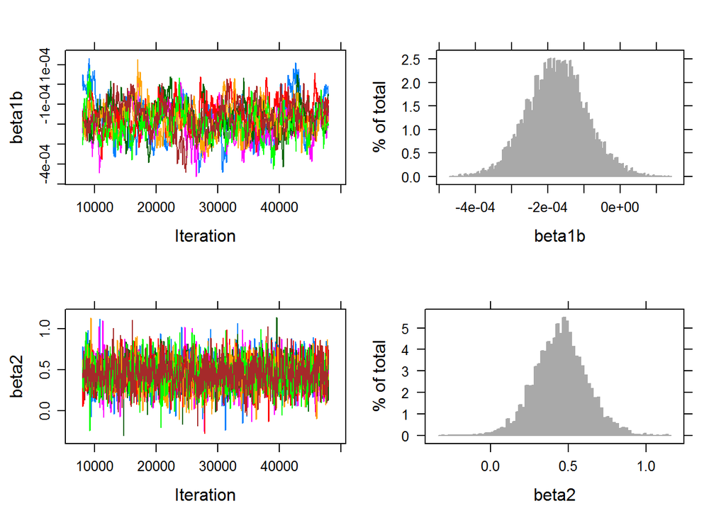

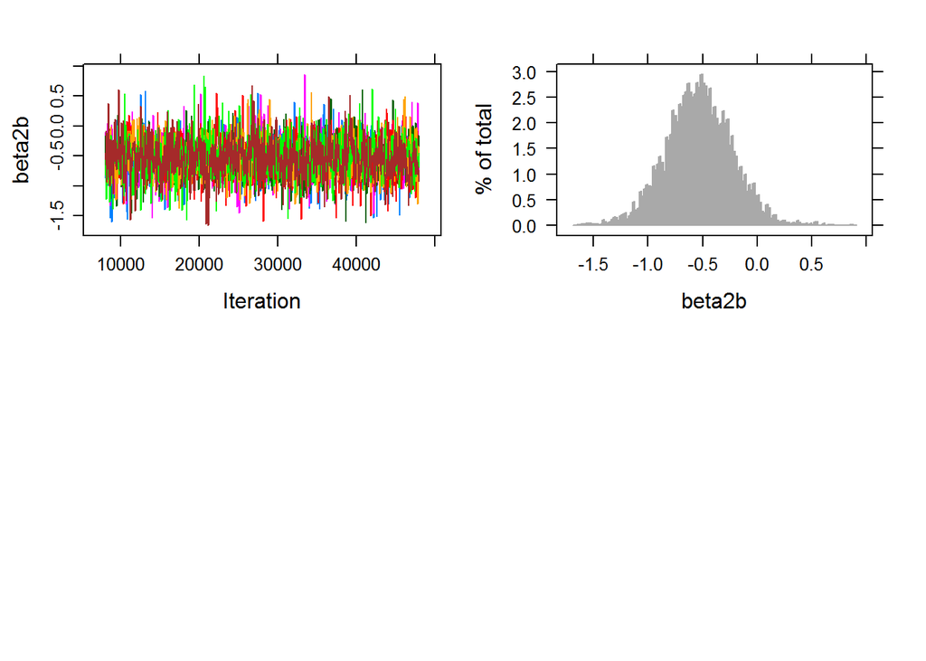

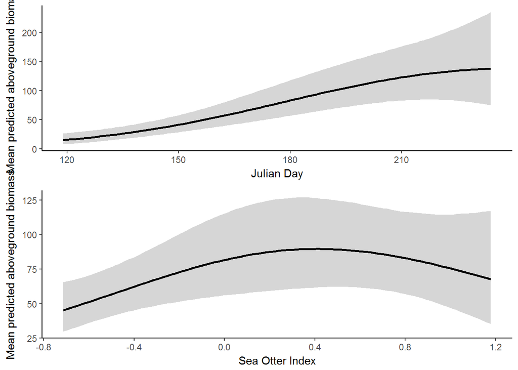